# Transformações do Mercado Agropecuário · Do Campo Commodity ao Agro de Valor

Gestão de Branding no Agro · Aula 01

Prof. Dr. Luiz Diego Vidal Santos

## Visão Geral

### Tópicos Principais

- 1 O agro brasileiro em números
- 2 De commodity a produto de valor
- 3 Mudanças no perfil do consumidor
- 4 Economia da atenção e diferenciação
- 5 A marca como resposta estratégica

**Objetivo da Aula**

Compreender as transformações estruturais do mercado agropecuário brasileiro e por que a gestão de marcas se tornou uma necessidade estratégica para o setor.

## O AGRO BRASILEIRO EM NÚMEROS

O agronegócio brasileiro representa uma potência produtiva global:

- **~27% do PIB** nacional (CNA, 2024)
- **3º maior exportador** de alimentos do mundo
- **Emprega ~27 milhões** de pessoas
- Responsável por alimentar mais de **1 bilhão de pessoas** globalmente

Mas essa grandeza produtiva esconde uma fragilidade: a maioria dos produtores **compete por preço**, não por **valor percebido**.

## QUANDO PRODUZIR BASTAVA

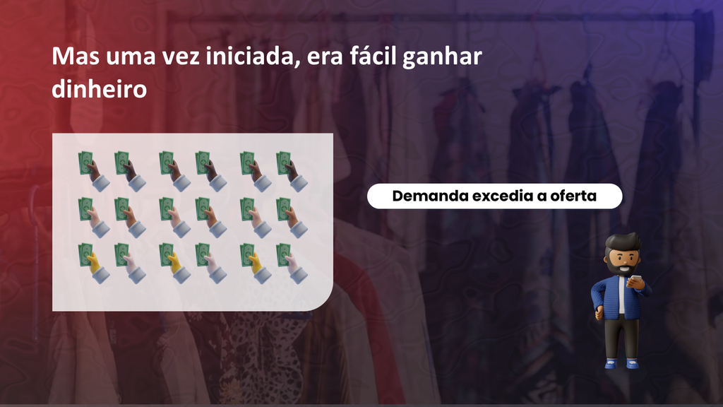

No passado, a demanda excedia a oferta: quem produzia, vendia

No modelo anterior, a simples capacidade de **produzir** já era suficiente para garantir mercado. A demanda superava a oferta e não havia necessidade de diferenciação.

## A ARMADILHA DA COMMODITY

### Lógica commodity

- Produto indiferenciado
- Competição por **preço e volume**
- Margem decrescente
- Poder de barganha no **comprador**
- Produtor é “tomador de preço”

### Lógica de marca

- Produto com identidade
- Competição por **valor percebido**
- Margem protegida
- Poder de barganha **compartilhado**
- Produtor define o posicionamento

> A commodity é precificada pelo mercado. A marca é precificada pela **percepção**.

## O MERCADO FICOU AGRESSIVO

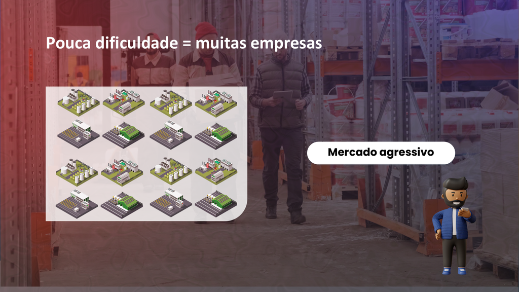

Quando a barreira de entrada diminui, o mercado se torna agressivo

## VOCÊ É SÓ MAIS UM?

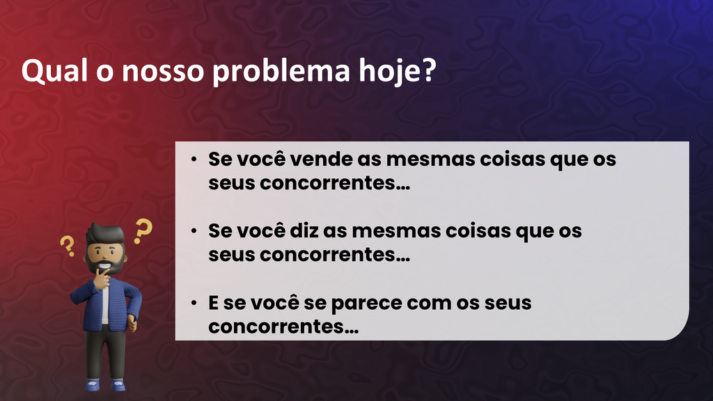

Sem diferenciação, a marca é invisível em meio à concorrência

## MUDANÇAS NO PERFIL DO CONSUMIDOR

O consumidor de alimentos mudou radicalmente nas últimas duas décadas:

| Antes | Agora |
| --- | --- |
| Comprava por preço | Compra por **história e valores** |
| Aceitava o disponível | Pesquisa e **escolhe ativamente** |
| Não questionava origem | Exige **rastreabilidade** |
| Marca = logotipo | Marca = **experiência e confiança** |
| Passivo | Ativo nas redes sociais |

O consumidor atual é um **auditor voluntário** das marcas que consome.

## ECONOMIA DA ATENÇÃO

Em um mundo com excesso de oferta, o recurso mais escasso não é o produto — é a **atenção**.

- Uma pessoa é exposta a **6.000–10.000** mensagens publicitárias por dia
- O tempo de atenção médio caiu para **~8 segundos**
- Apenas marcas **relevantes e diferenciadas** conseguem furar esse filtro

**Aviso**

Se sua marca não comunica valor em poucos segundos, ela é invisível.

## PREÇO NÃO É DIFERENCIAL

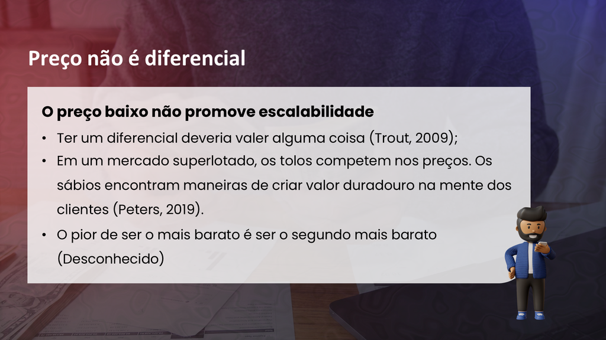

O preço baixo não promove escalabilidade nem sustentabilidade da marca

## A MARCA COMO RESPOSTA

A marca resolve os três principais desafios do agro contemporâneo:

| Desafio | Solução via marca |
| --- | --- |
| Commoditização | Diferenciação e identidade |
| Margens apertadas | Prêmio de preço por valor percebido |
| Invisibilidade do produtor | Narrativa, origem e rastreabilidade |

A marca transforma o protagonismo produtivo em **protagonismo de mercado**.

## O QUE É UM DIFERENCIAL?

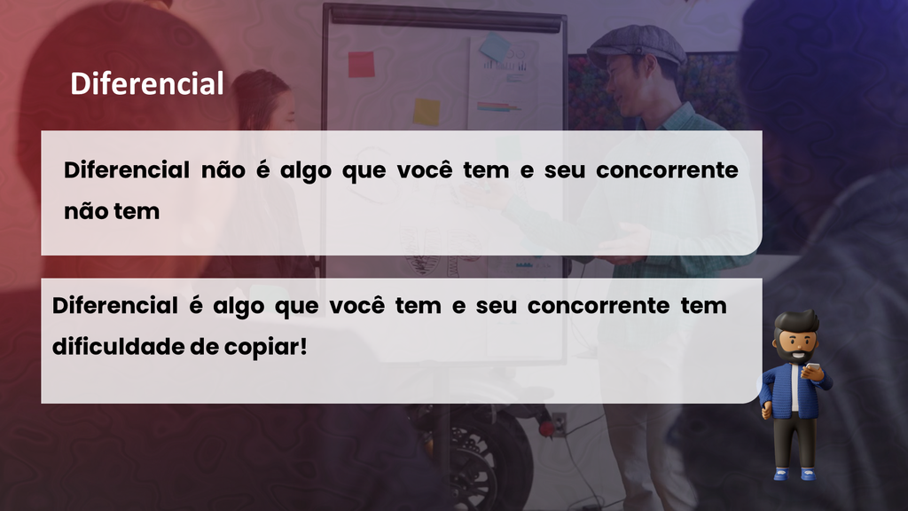

Diferencial é algo que você tem, seu concorrente tem dificuldade de copiar e seu cliente percebe como valor

## O NOVO PARADIGMA

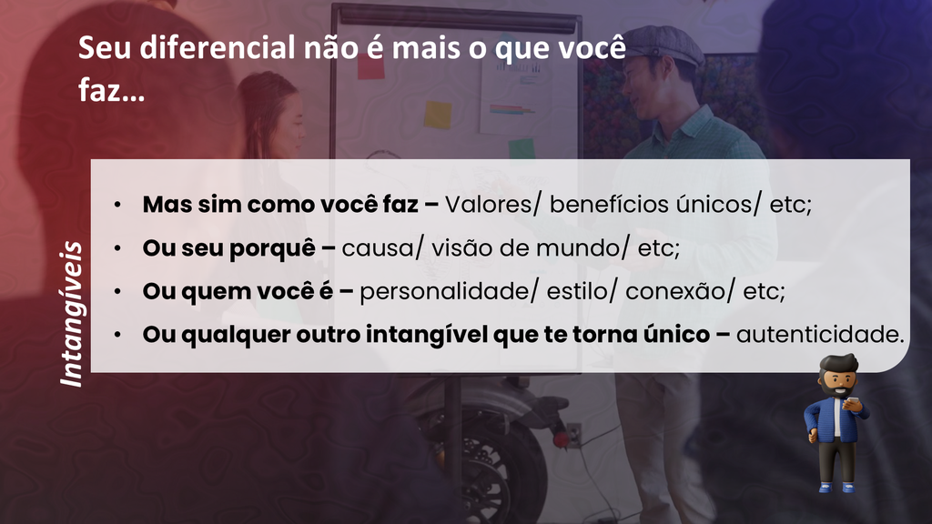

O diferencial não está mais no que se faz, mas em como e por quê se faz

## EXEMPLOS DE TRANSFORMAÇÃO

### Café commodity → Café de terroir

- Mesmo produto, mesma região
- Sem marca: R$ 30/kg (commodity)
- Com marca: R$ 80–120/kg (especial)
- Diferença: **narrativa + rastreabilidade + posicionamento**

### Mel genérico → Mel monofloral de origem

- Mesmo apiário, mesma produção
- Sem marca: R$ 15/kg (balde)
- Com marca: R$ 55/kg (fracionado, com selo)
- Diferença: **identidade + embalagem + benefícios comunicados**

## PARA A PRÓXIMA AULA

### Atividade Preparatória

1. Pense em **um produto agro** que você conhece que é vendido como commodity
2. Identifique **o que falta** para esse produto ter uma marca reconhecida
3. Liste **3 atributos** que o diferenciariam dos concorrentes

Estas reflexões serão usadas na Aula 02: **Introdução ao Branding**.

## REFERÊNCIAS

- CNA. PIB do Agronegócio Brasileiro. Panorama do Agro, 2024.
- IBGE. Censo Agropecuário Brasileiro, 2024.
- MAPA. Anuário Estatístico: Agrostat, 2024.
- KOTLER, P.; KARTAJAYA, H.; SETIAWAN, I. *Marketing 4.0*. Wiley, 2017.
- TROUT, J.; RIVKIN, S. *Diferenciar ou Morrer*. Futura, 2000.